# Spatial-Temporal Distribution of Kinkajous in a Balsa Tree

## Kinkajou Decisions

We look at whether the difference in adjusted counts between regions had any impact on decisions the kinkajous made. Here, a success means the kinkajou went to the region with the greater adjusted flower count. We look at the frequencey of success realtive to the magnitude of difference in adjusted flower count between the regions the kinkajou was choosing between.

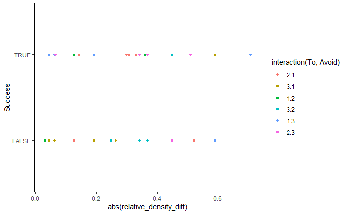

```r
ggplot(na.omit(decisions)) + geom_point(aes(x = abs(relative_density_diff), y = Success, color = interaction(To, Avoid))) +
  theme_classic()
```

By appearance, the adjusted flower count does not have an effect on kinkajou decisions

## Summary Statistics

Below, we extract some descriptive statistics for describing some of the patterns in kinkajous residence time and flower counts visualized throughout the plots in this section.

```r
#means and standard deviation of kinkajou movement
mean_residence <- mean(kinkajou_counts$Minutes_Per_Hour)
var_residence <- sd(kinkajou_counts$Minutes_Per_Hour)
mean_residence_by_region <- group_by(kinkajou_counts_region, Region) %>% dplyr::summarise(Mean = mean(Minutes_Per_Hour), Standard_Deviation =sd(Minutes_Per_Hour))
mean_residence_by_region$Region <- mean_residence_by_region$Region %>% as.character()
mean_residence_by_region <- mean_residence_by_region %>% rbind(c("all", mean_residence, var_residence))
mean_residence_by_region$Units <- "minutes per hour"
mean_residence_by_region
```

| Region | Mean | Standard_Deviation | Units |
| --- | --- | --- | --- |
| 1 | 6.5056774067488 | 7.43880078303258 | minutes per hour |
| 2 | 9.5129100608748 | 9.54173224269401 | minutes per hour |
| 3 | 9.20903668144021 | 10.6482131254108 | minutes per hour |
| all | 25.2276241490638 | 22.9150176194953 | minutes per hour |

```r
#means and standard deviation of balsa flower
mean_flowers_counts <- mean (flower_counts$Count)
var_flower_counts <- sd(flower_counts$Count)
mean_flower_counts_by_region <- group_by(flower_counts_region, Region) %>% summarise(Mean = mean (Count), Standard_Deviation = sd (Count))
mean_flower_counts_by_region$Region <- mean_flower_counts_by_region$Region %>% as.character()
mean_flower_counts_by_region <- mean_flower_counts_by_region %>% rbind(c("all", mean_flowers_counts, var_flower_counts))
mean_flower_counts_by_region$Units <- "Flowers"
mean_flower_counts_by_region
```

| Region | Mean | Standard_Deviation | Units |
| --- | --- | --- | --- |
| 1 | 27.5 | 11.6669467753489 | Flowers |
| 2 | 41.25 | 19.4567771347309 | Flowers |
| 3 | 19.3055555555556 | 9.22454986768666 | Flowers |
| all | 88.0555555555556 | 38.4646089774854 | Flowers |

```r
combined_summary_statistics <- rbind(mean_residence_by_region, mean_flower_counts_by_region)
combined_summary_statistics
```

| Region | Mean | Standard_Deviation | Units |
| --- | --- | --- | --- |
| 1 | 6.5056774067488 | 7.43880078303258 | minutes per hour |
| 2 | 9.5129100608748 | 9.54173224269401 | minutes per hour |
| 3 | 9.20903668144021 | 10.6482131254108 | minutes per hour |
| all | 25.2276241490638 | 22.9150176194953 | minutes per hour |
| 1 | 27.5 | 11.6669467753489 | Flowers |
| 2 | 41.25 | 19.4567771347309 | Flowers |
| 3 | 19.3055555555556 | 9.22454986768666 | Flowers |
| all | 88.0555555555556 | 38.4646089774854 | Flowers |

```r
paste("mean kinkajou residence in the entire tree, minutes per hour", mean_residence,
      "standard deviation of kinkajou residence in entire tree, minutes per hour", var_residence,
      "mean flower count in entire tree by day", mean_flowers_counts,
      "standard deviation of mean flower count in entire tree by day", var_flower_counts, sep=" ")
```

```
[1] "mean kinkajou residence in the entire tree, minutes per hour 25.2276241490638 standard deviation of kinkajou residence in entire tree, minutes per hour 22.9150176194953 mean flower count in entire tree by day 88.0555555555556 standard deviation of mean flower count in entire tree by day 38.4646…
```